# Transit of Earth and Moon (and Phobos) from Mars on 2084-11-10

Yu-Ann Wang

20/01/2017

## In orbit

On 10th of November 2084, the orbits of Earth and Mars will align such that when viewed from Mars, both Earth and the Moon will transit across the disk of the Sun. Here is a representation of what a viewer may expect to see.

As always, please remember to wear **solar-filters** for a safe viewing experience. Do **NOT** look at the sun directly with naked eyes.

Ephemeris data courtesy of the wonderful NASA JPL’s [Horizons On-Line Ephemeris System](http://ssd.jpl.nasa.gov/?horizons).

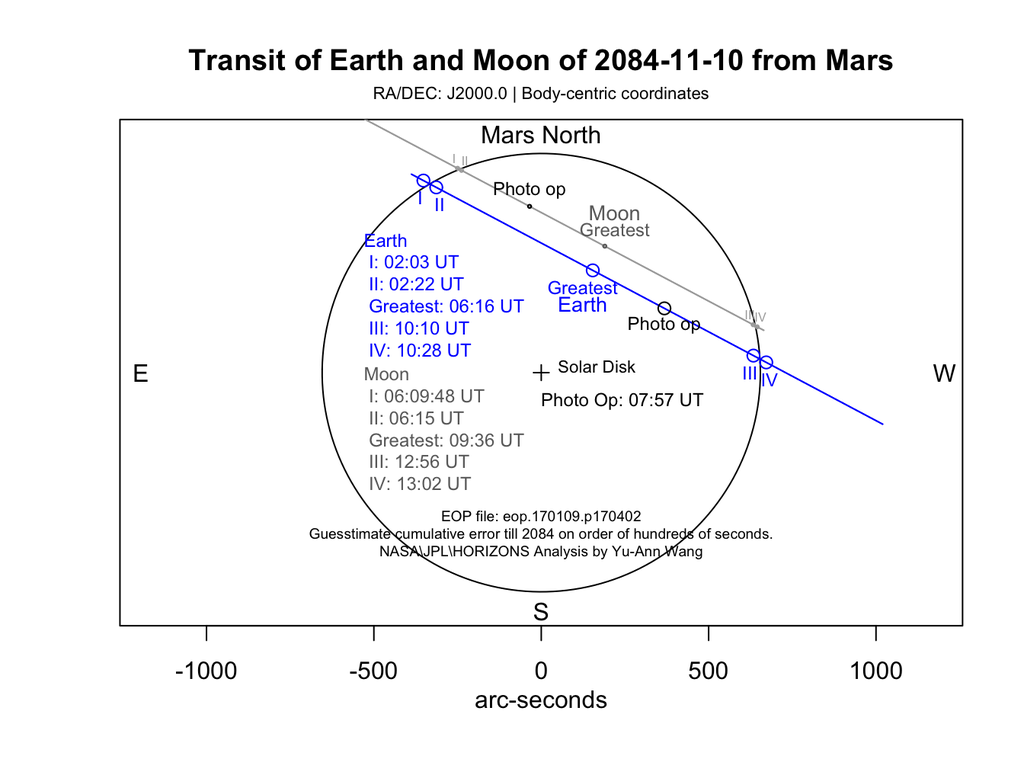

It goes without saying that the night-side of the Earth will be facing Mars during the transit. At the start of the Earth transit at 02:03 UT, Europe, Africa and the Atlantic will be Mars-facing. By the end at of the Earth transit at 10:28 UT, the Americas and the Pacific will be Mars-facing. More of the Earth’s northern hemisphere will be visible as the southern hemisphere inclines towards the Sun in November [as in this 2016-11-20 HiRISE image of Earth-Moon from Mars](http://www.jpl.nasa.gov/spaceimages/details.php?id=PIA21260). Resolving the familiar night-time city lights of human civilisation from Mars while the Earth is silhouetted against the solar disk is likely an interesting photography challenge.

The public science outreach potential of this event will be immense. In-person viewing will have the most impact from an individual’s engagement perspective (including the [overview effect](https://en.wikipedia.org/wiki/Overview_effect)). Real-time web-casts from space-telescopes or other satellites in orbit around Mars will increase the reach and message spread considerably. ([Ref SOA coverage of the Venus Transit 2012](https://www.nasa.gov/mission_pages/sunearth/multimedia/venus-transit-2012.html))

The lead time available till 2084 offers ample lead time for interested parties to mount an expedition and put hardware and communications in place.

## From the surface

2084 November 10th falls in the [Month 11 of the Martian year](http://www-mars.lmd.jussieu.fr/mars/time/martian_time.html), which is the middle of the Martian Dust Storm Season. Now, should the weather hold with clear skies, it will be possible to view the transit from the Martian surface.

A number of viewing sites are considered. These are either historical landing sites, or locations where future infrastructure is considered. Future sites are from the [Mars 2020 landing site short list](http://marsnext.jpl.nasa.gov/workshops/wkshp_2017_02.cfm), and the [proposed Exploration Zones (EZ)](https://www.nasa.gov/journeytomars/mars-exploration-zones) from the 2015 HLS<sup>2</sup> workshop. Elevation details, where not provided, are estimated from [MOLA](https://attic.gsfc.nasa.gov/mola/images.html) imagery.

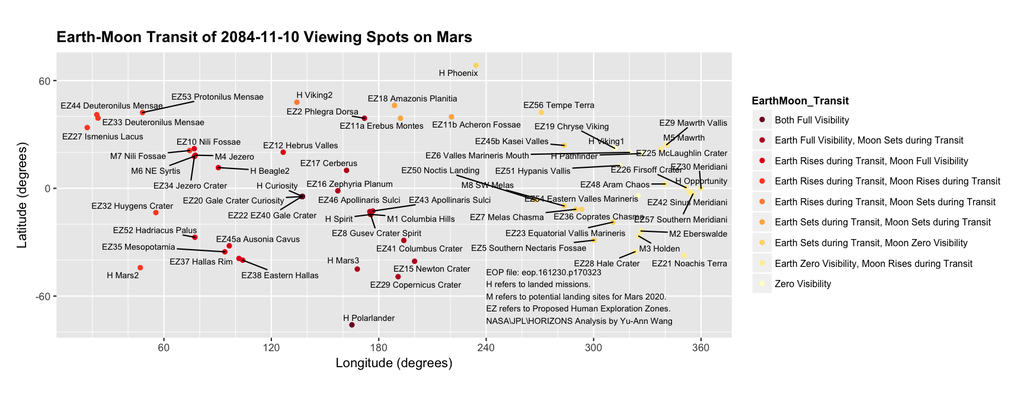

The best sites will be ones where

- the sun will be high above the horizon (high elevation) for better viewing
- both transits can be seen
- if not, Earth is prioritized for public outreach reasons

Also, ideally, any such site should have provisions for a decent observatory / telescope set-up, which implies supporting infrastructure. An EZ can provide this: targetted to land in the 2030s (or ‘within the next 50 years’), an EZ will make an ideal base for further settlement-based activities.

## Phobos

The Moon is often an interfering body in Earth-based astronomy. It interferes by ‘polluting’ the night-sky with moonlight when it is above the horizon, interfering with the observation of non-Lunar objects. Phobos, the larger moon of Mars, appears as an interfering body in the sky during the transit time frame. This, however, offers an intriguing opportunity for a triple-transit. Due to its ‘potatoroid’ shape, Phobos has an angular diameter anywhere between 660 to 830 arc-seconds when viewed from the surface of Mars (over the period analysed), which is not quite large enough to fully eclipse the disk of the Sun, which has an angular diameter of 1308.9 arc-seconds. [Curiosity captured such a transit](https://www.nasa.gov/mission_pages/msl/multimedia/pia17356.html) back in 2013. The triple-transits will be observable at Phobos’s sub-solar points (i.e. directly beneath its shadow) as it travels across the sky.

Here is a list of the ground locations where Phobos will come closer than five degrees to the Sun and the Earth during this transit. *Curiosity* is referenced for reference.

```
## [1] "Azimuth and Elevation (degrees) refer to Earth's Azimuth and Elevation in the sky. Minimum TOI refers to the closest separation (in between Phobos and Earth, and what time it does so."
```

```
##   n                   site Azimuth(d) Elevation(d) Min. TOI(d)  When
##   1    EZ11a Erebus Montes   243.1825       8.2432       1.040 08:29
##   2      EZ2 Phlegra Dorsa   227.3198      21.7041       2.341 08:25
##   3 EZ18 Amazonis Planitia   239.5749       7.2634       2.956 08:27
##   4     EZ12 Hebrus Valles   172.7765      54.7872       3.418 08:09
##   5       EZ10 Nili Fossae   117.3509      21.7209       4.729 07:50
##  14            H Curiosity   215.5640      77.1609      16.600 08:14
```

Unfortunately, none of these locations are in the direct path of Phobos’s shadow.

What if overland travel is possible? Then, of these five EZ

- EZ11a Erebus Montes offers a shortest drive to a triple transit viewing point
- EZ12 Hebrus Valles is the staging point to the highest-elevation viewing point if distance is less of a concern

Let’s take a walk drive.

### EZ11a Erebus Montes

With only 1.04 degrees separating Earth and Phobos at closest approach, EZ11a Erebus Montes (192.1E, 39N) is a good candidate from which to search for a triple transit viewing point. Proceeding due south, at (192.1E, 36N), approximately 177km away (which is an significant distance compared to the 100km wide EZ) a partial triple transit (figure left below) is expected. Another 0.5 degree south to (192.1E, 35.5N) (approximately 30km), a full triple transit (figure right below) is expected. However, the Sun will be only 9.6 degrees above the horizon at the time of the transit.

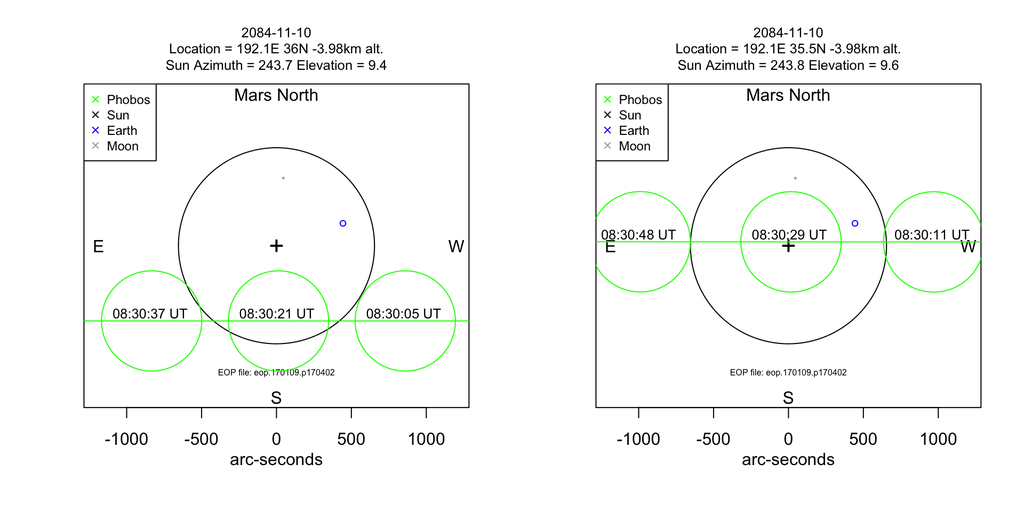

*Caveat: As Phobos is not spherical (but a potatoroid), the Phobos disk drawn is an approximation.*

Note that Phobos’s transit is complete within **one minute**. This is due to Phobos’s very short orbital period of 7 hours 39.2 minutes. It moves around Mars faster than Mars itself rotates, which is why it rises in the West and sets in the East. Phobo’s small size and short orbital period result in a high sensitivity of transit visibility to latitude.

There is lower sensitivity to longitude as Phobos’s inclination is only 1 degree to Mars’ equator. The following shows the view at locations 0.5 degrees West (figure left below) and East (figure right below) of (192.1E, 35.5N) respectively.

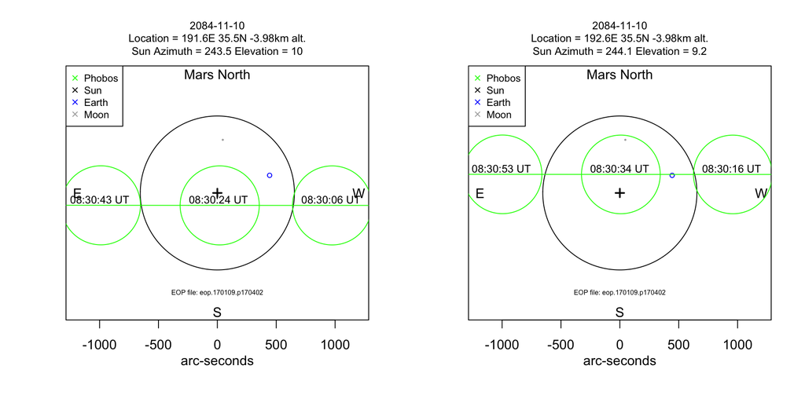

### EZ2 Phlegra Dorsa

The same ‘proceed south’ routine from EZ2 Phlegra Dorsa (172E, 39N) brings the triple transit into view at (172E, 31.25N), approximately 458km (figure below) away from the EZ.

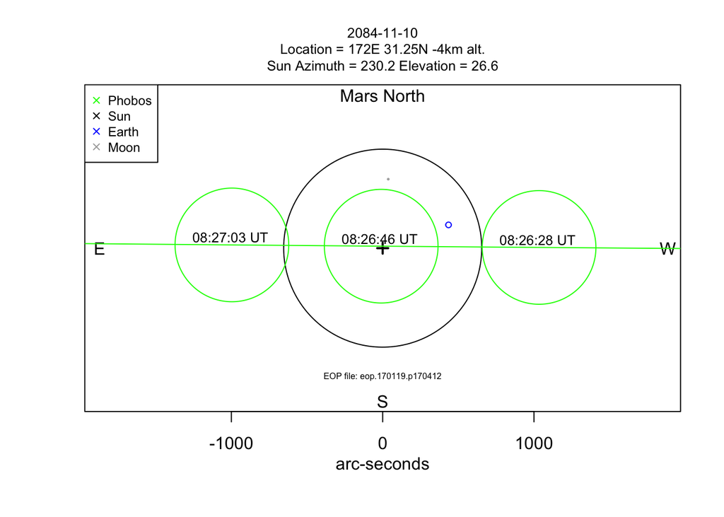

### EZ18 Amazonis Planitia

The same ‘proceed south’ routine from EZ18 Amazonis Planitia (188E, 46.16N) brings the triple transit into view at (188E, 34.6N), approximately 684km (figure below) from the EZ.

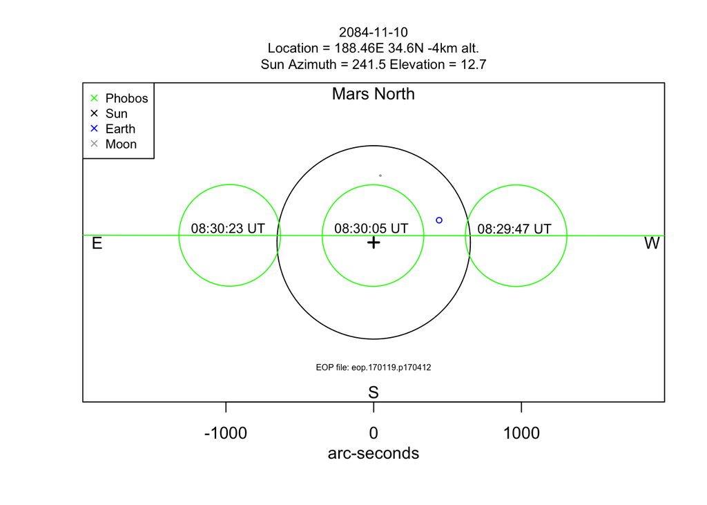

### EZ12 Hebrus Valles

A ‘proceed north’ routine from EZ12 Hebrus Valles (126.6E, 20.1N) brings the triple transit into view at (126.6E, 28.3N), approximately 486km (figure below) from the EZ.

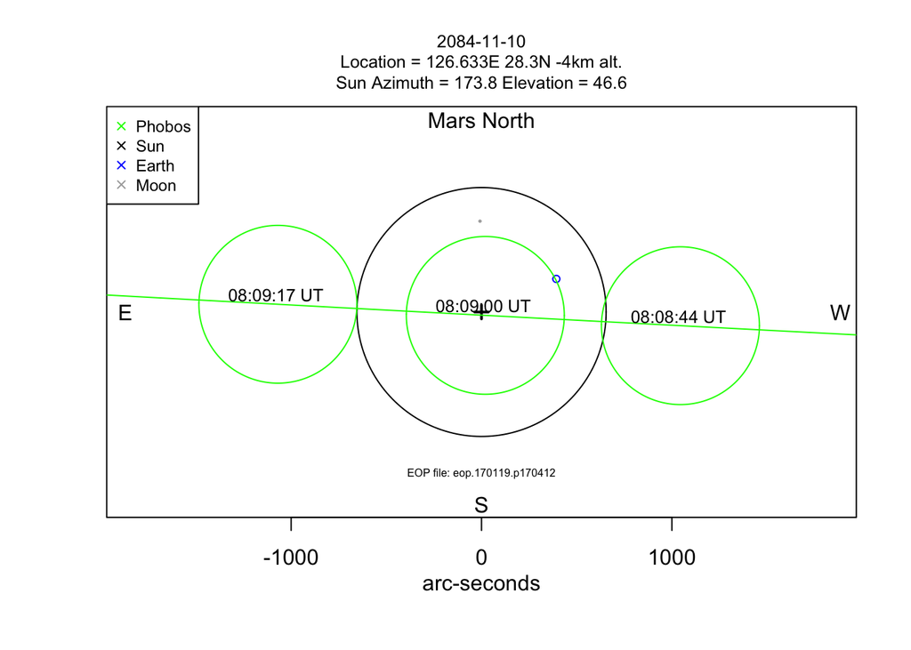

### EZ10 Nili Fossae

The same ‘proceed north’ routine from EZ10 Nili Fossae (76.95E, 22.05N) brings the triple transit into view at (76.95E, 35.5N), approximately 796km (figure below).

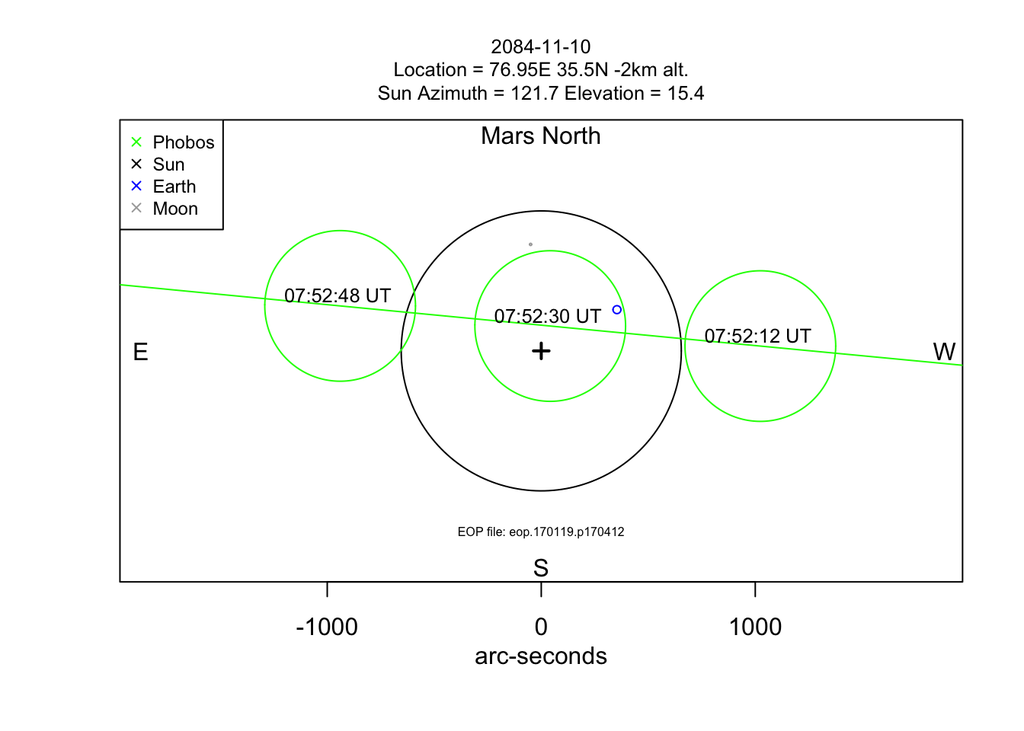